# Data Preparation: Transformations - Exercises

Eric Cai

7/4/2019

## 4(C) DATA TRANSFORMATIONS: EXERCISES

### Question 1

Loading all of the necessary packages:

```r
library(datasets)
library(tidyverse)
library(gridExtra)
library(grid)
library(png)
library(downloader)
library(grDevices)
library(caret)
```

Creating two dataframes: *unscaled.weights* and *scaled.weights*. As you can probably guess, the former will contain the original weight data and the latter will contain the standardized weight data.

```r
unscaled.weights <- data.frame(ChickWeight$weight)
scaled.weights <- data.frame(scale(ChickWeight$weight))

# renaming the column containing weights as "weight"
names(unscaled.weights)[1] <- "weight"
names(scaled.weights)[1] <- "weight"
```

Then we plot both data sets on histograms side by side to compare their distribution:

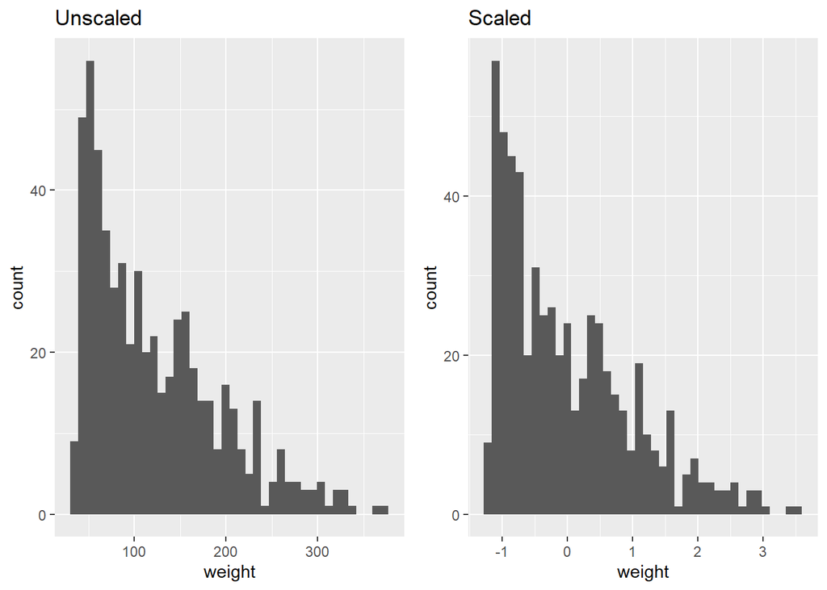

We can see pretty clearly that standardizing the data does not affect the shape of the distribution. Scaling the data only changed its range.

Now let’s look at the quantile-quantile plots for these distributions:

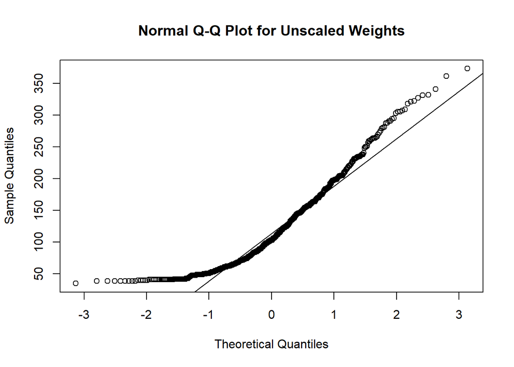

```r
# plotting for unscaled weights
qqnorm(unscaled.weights$weight, main = "Normal Q-Q Plot for Unscaled Weights")
qqline(ChickWeight$weight)
```

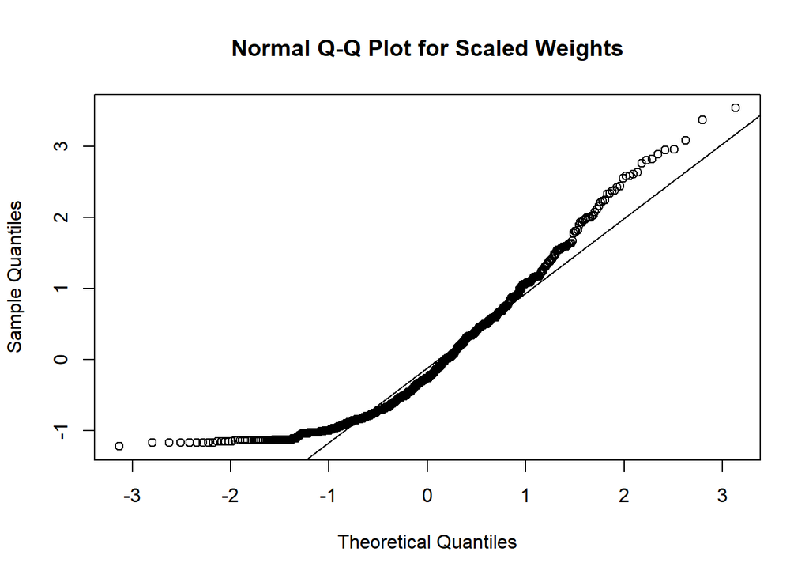

```r
#plotting for scaled weights
qqnorm(scaled.weights$weight, main = "Normal Q-Q Plot for Scaled Weights")
qqline(scaled.weights$weight)
```

Once again, the shape of the plots are exactly the same. This makes sense: Q-Q plots compare distributions (in this case the two weight distributions to a normal distribution). Since the scaled weights maintain the same shape distribution as the original weights, we should expect no difference in the shape of the Q-Q plots.  
As for the results themselves, we can see quite clearly that the distribution of the weights is positively skewed.

Now let’s apply some transformations:

```r
# Note: the transformations should only be done to the unscaled data. The scaled data has many negative values, which will become NaN's if transformed. Since NaN's cannot be plotted, they will be ignored, which can significantly alter the distribution (intuitively, most of these NaN's will be pulled from the left tail of the distribution, since that is where we expect most of the negative numbers to be).

# log transformation
unscaled_log <- transform(unscaled.weights, weight.log = log(weight))

# sqrt transformation
unscaled_sqrt <- transform(unscaled.weights, weight.sqrt = sqrt(weight))
```

Let’s look at the Q-Q plots for these transformations:

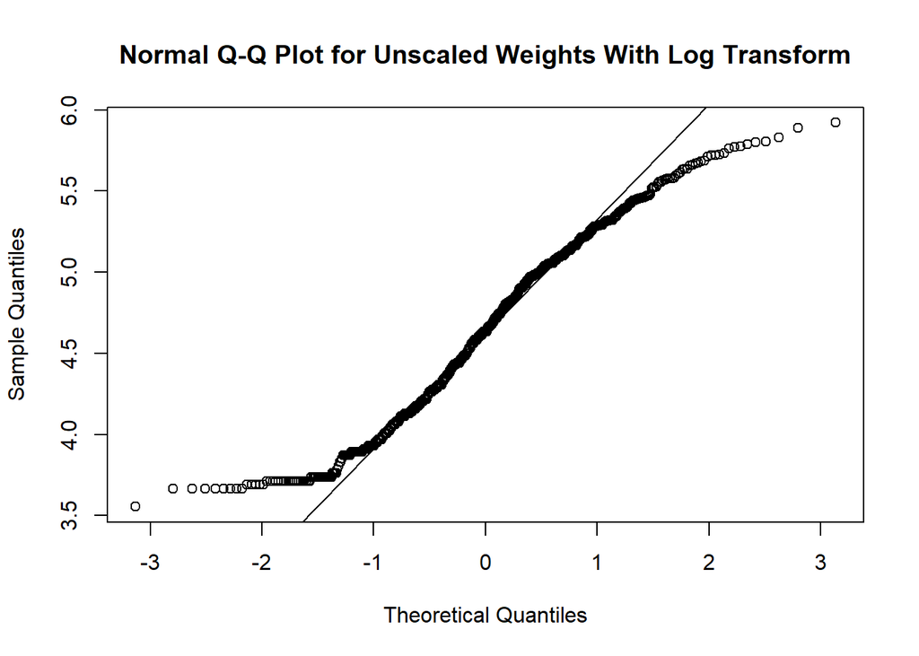

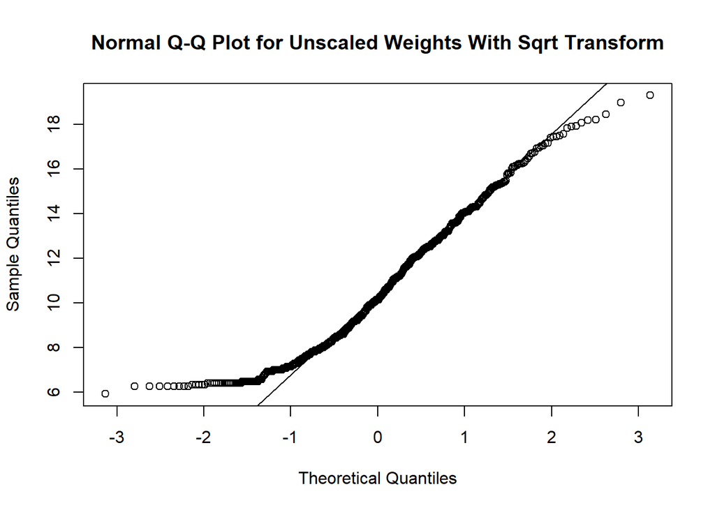

How about the Box-Cox transformation?

```r
unscaled_boxcox <- BoxCoxTrans(unscaled.weights$weight, fudge = 0.05)
unscaled_boxcox
```

```
## Box-Cox Transformation
##
## 578 data points used to estimate Lambda
##
## Input data summary:
##    Min. 1st Qu.  Median    Mean 3rd Qu.    Max.
##    35.0    63.0   103.0   121.8   163.8   373.0
##
## Largest/Smallest: 10.7
## Sample Skewness: 0.959
##
## Estimated Lambda: 0
## With fudge factor, Lambda = 0 will be used for transformations
```

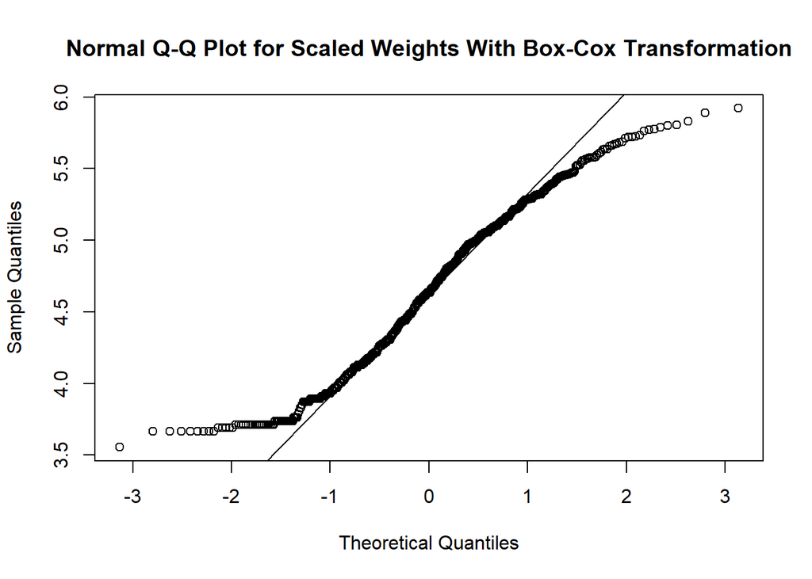

```r
unscaled_boxcox <- data.frame(predict(unscaled_boxcox, unscaled.weights$weight))
# renaming the column containing the weights to "weight"
names(unscaled_boxcox)[1] <- "weight"
```

Interestingly enough, the *BoxCoxTrans* function used a lambda of 0. This corresponds directly to a log transformation, and the resulting Q-Q plot seems to reflect this as it is identical to the Q-Q plot of the log transformation.

### QUESTION 2

First, let’s generate our samples.

```r
# Sampling from normal distribution
sample.norm <- rnorm(1000, 0, 0.25)

# Sampling from exponential distribution
sample.exp <- rexp(1000, 10)
```

Now, for the plots:

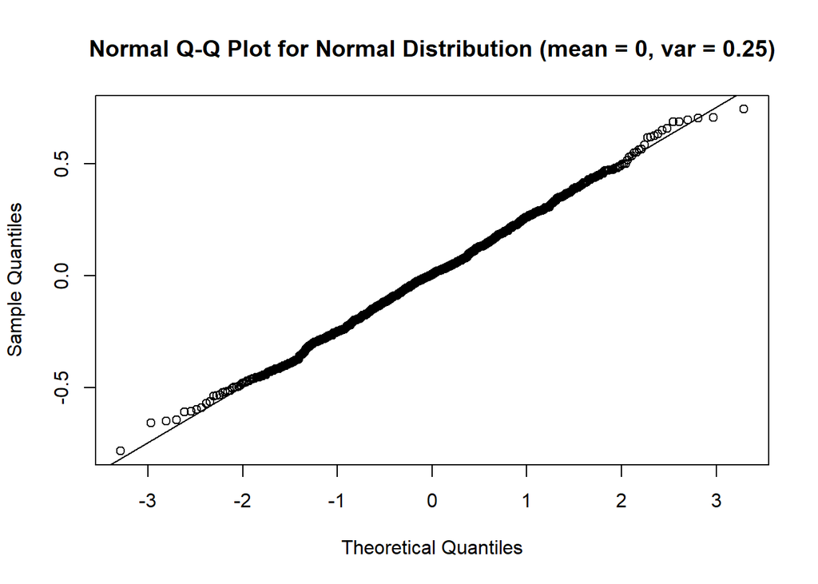

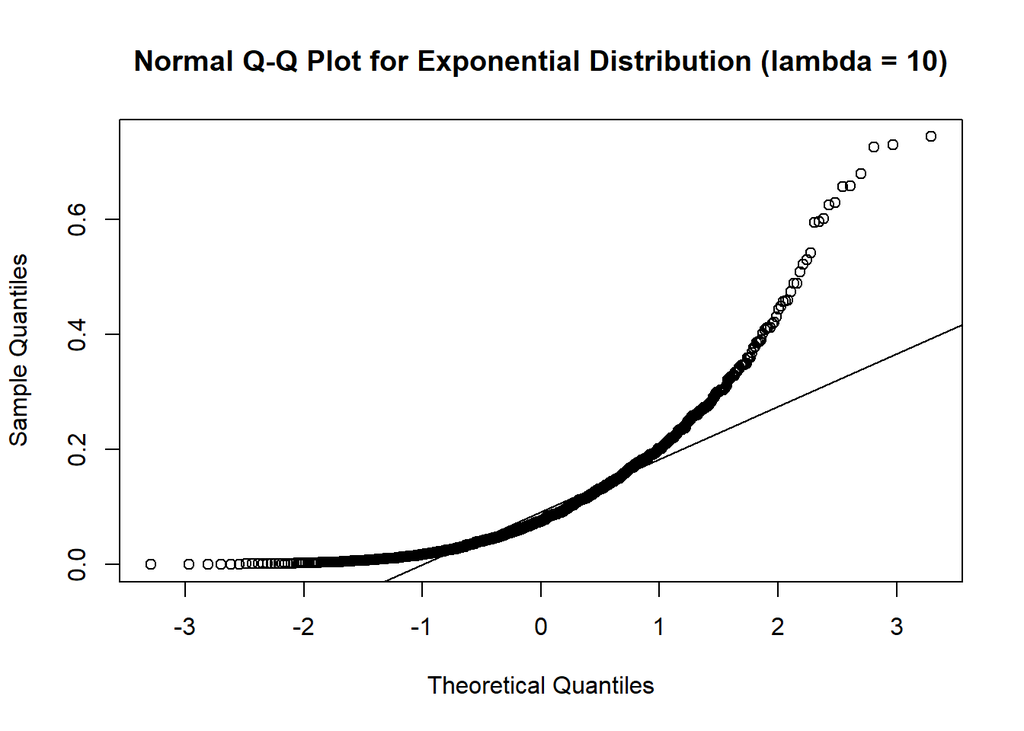

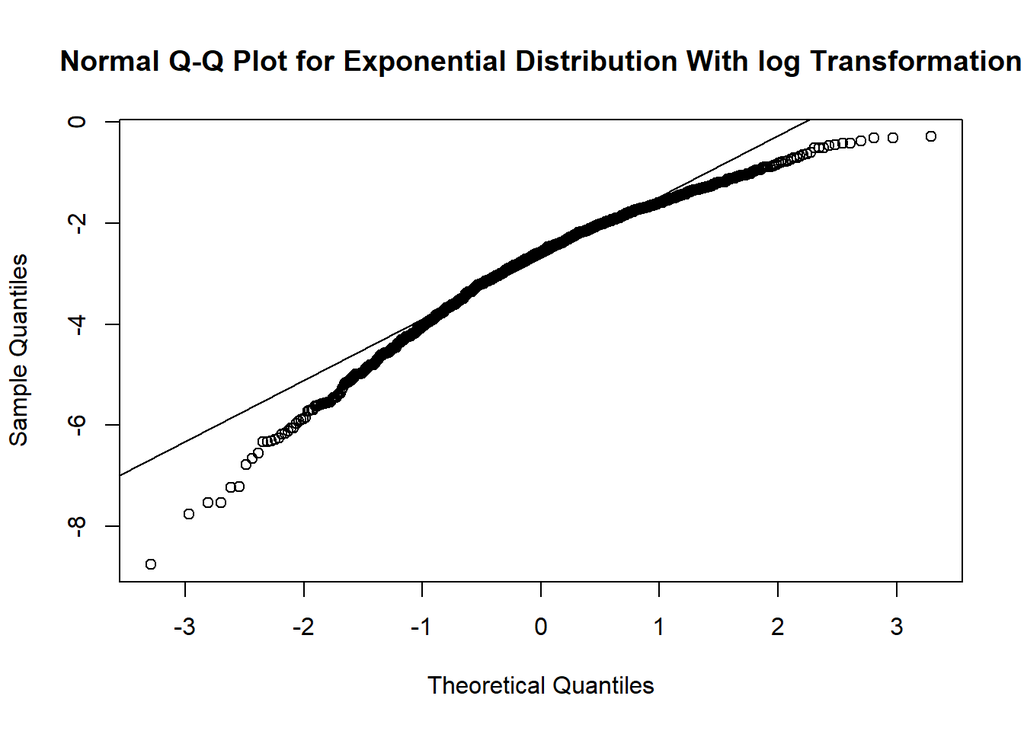

We can also look directly at the distributions for these data sets:

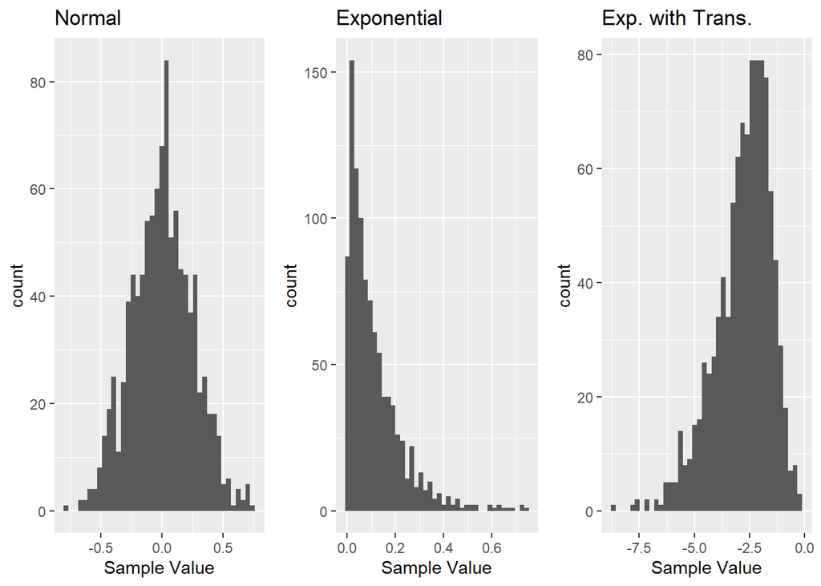

Ultimately, we can see from the histograms and the Q-Q plots that negatively skewed distributions will stay under their respective theoretical lines - the opposite holds for positively skewed distributions. We can also see from the histograms that the log transform (and presumably the sqrt transform as well) pushes the skew of the distribution in the negative direction. It follows then that an exponential transform or a power transform (with a power greater than 1) will push the skew of a distribution in the positive direction. It seems, then, that if we want to fit a given distribution to a normal shape, we can apply a log or a sqrt transform if the original data is positivevly skewed, and an exponential or power transform if the original data is negatively skewed.